# Cocoa Price Forecasting: Weighted Local Linear vs Machine Learning Methods

**Project:** Empirical Validation of the CGS Weighted Local Linear Framework

**Reference:** CGS (2025) - Nonparametric Time Series Forecasting with Structural Breaks

## Abstract

This notebook implements the experimental framework to validate the CGS weighted local linear methodology on cocoa price data.

### Models Evaluated

| Category | Model | Data Usage | Description |
| --- | --- | --- | --- |
| NP Benchmarks | Pre-Break LL | Pre-break only | High bias, low variance baseline |
|  | Post-Break LL | Post-break only | Low bias, high variance baseline |
|  | Weighted LL (WLL) | Combined | CGS convex combination with MFV-tuned gamma |
| ML Competitors | Random Forest | Full sample | Ensemble bagging method |
|  | XGBoost | Full sample | Gradient boosting method |
| ML Extension | RF Weighted Combo | Combined | CGS weighting applied to RF |
|  | XGB Weighted Combo | Combined | CGS weighting applied to XGB |

### Evaluation Metrics

- **Primary:** Out-of-Sample Mean Squared Forecast Error (MSFE)
- **Secondary:** Modified Diebold-Mariano (MDM) test for pairwise comparisons

## 1. Environment Setup

```
Dependencies installed successfully.
```

```
Standard libraries imported.
```

```
Project modules imported.
```

## 2. Data Loading and Exploration

```
Dataset: 6,734 observations
Date range: 1994-10-04 to 2025-02-26
Columns: ['date', 'PRCP_anom_mean', 'TAVG_anom_mean', 'PRCP_anom_std', 'TAVG_anom_std', 'N_stations', 'log_price', 'log_price_lagt', 'log_return', 'log_return_forecast_target']
```

|  | date | PRCP_anom_mean | TAVG_anom_mean | PRCP_anom_std | TAVG_anom_std | N_stations | log_price | log_price_lagt | log_return | log_return_forecast_target |
| --- | --- | --- | --- | --- | --- | --- | --- | --- | --- | --- |
| 0 | 1994-10-04 | 0.0000 | 0.25 | 0.000000 | 0.000000 | 1 | 7.287752 | 7.290457 | -0.002704 | -0.021924 |
| 1 | 1994-10-05 | 0.0925 | 0.00 | 0.137886 | 2.828427 | 2 | 7.265828 | 7.287752 | -0.021924 | -0.000175 |
| 2 | 1994-10-06 | 0.0040 | -0.40 | 0.005657 | 0.565685 | 2 | 7.265653 | 7.265828 | -0.000175 | -0.009737 |
| 3 | 1994-10-07 | -0.0284 | 0.46 | 0.377151 | 1.306905 | 5 | 7.255916 | 7.265653 | -0.009737 | -0.001929 |
| 4 | 1994-10-10 | -0.4325 | -4.00 | 0.000000 | 0.000000 | 1 | 7.253987 | 7.255916 | -0.001929 | 0.000149 |

```
Structural Break Configuration:
  Break Index: 6116
  Break Date: 2022-09-23
  Pre-break observations: 6,116
  Post-break observations: 618
```

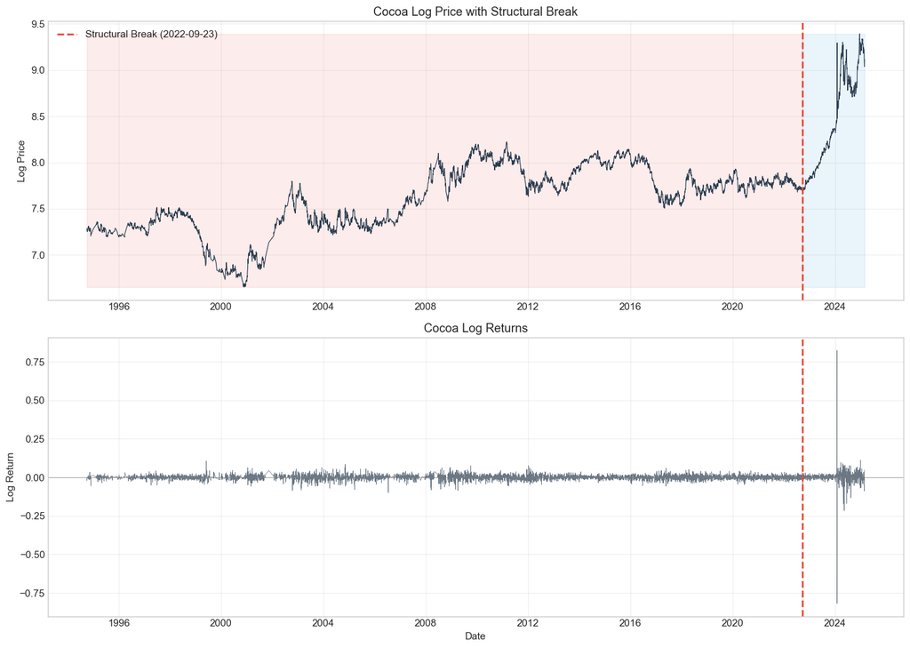

```
Summary Statistics by Regime:
  Pre-break  - Mean: 0.000075, Std: 0.015553, N: 6116
  Post-break - Mean: 0.002491, Std: 0.071729, N: 618
```

### Methodology: Mohr-Selk (2020)

We use the Mohr-Selk (2020) detector to locate the structural break. Steps are simple: (1) pick a pilot bandwidth with MFV for a local linear fit, (2) fit the pilot mean and take residuals, (3) scan candidate break points over a trimmed sample and choose the one with the largest KS-type statistic. The series is treated as strong mixing within each regime. In practice here, the detector lands on break index 6117 (2022-09-23), matching the configured break date.

```
Running Mohr-Selk (2020) Break Detection...
============================================================
Sample size for break detection: T = 6694
Dimension: d = 1

Step 1: Selecting pilot bandwidth via MFV cross-validation...
LocalPolynomialEngine will use device: cuda
Creating bandwidth grid with T=6694, d=1
Generated bandwidth grid: [0.01717366 0.02864739 0.04778673 0.07971307 0.13296941 0.22180635
 0.36999529 0.61718934 1.02953386 1.71736599]
Set block size to 1338 for training length 6694 and Q=4.
  Selected pilot bandwidth: h = 1.7174
  Pilot MFV MSE: 0.000813

Step 2: Computing pilot estimates...
  Pilot estimates computed for 6694 observations

Step 3: Estimating break date via KS functional maximization...

Results:
  Estimated break index (1-based): 6117
  Estimated break date: 2022-09-23
  Configured break index: 6117
  Configured break date: 2022-09-23
```

```
LocalPolynomialEngine will use device: cuda
Instantiated runner for NP_LL_Combo. Results will not be saved.
Structural break date identified: 2022-09-20
Full train/CV size: 6694, OOS test size: 40

--- (1/3) Tuning bandwidth for PRE-break model ---
Creating bandwidth grid with T=6113, d=1
Generated bandwidth grid: [0.01748836 0.02917235 0.0486624  0.08117378 0.13540603 0.22587087
 0.37677533 0.62849912 1.04839973 1.74883615]
Set block size to 1222 for training length 6113 and Q=4.
Best bandwidth for PRE-break model: 1.7488

--- (2/3) Tuning bandwidth for POST-break model ---
Creating bandwidth grid with T=581, d=1
Generated bandwidth grid: [0.02800043 0.04670754 0.07791287 0.1299665  0.2167972  0.36163952
 0.60325108 1.00628345 1.67858196 2.80004347]
Set block size to 116 for training length 581 and Q=4.
Best bandwidth for POST-break model: 2.8000

--- (3/3) Tuning gamma for Convex Combination model ---
Set block size to 116 for training length 581 and Q=4.
  Gamma: 0.00, MFV MSE: 0.006723
  Gamma: 0.05, MFV MSE: 0.006722
  Gamma: 0.10, MFV MSE: 0.006722
  Gamma: 0.15, MFV MSE: 0.006722
  Gamma: 0.20, MFV MSE: 0.006721
  Gamma: 0.25, MFV MSE: 0.006722
  Gamma: 0.30, MFV MSE: 0.006722
  Gamma: 0.35, MFV MSE: 0.006722
  Gamma: 0.40, MFV MSE: 0.006723
  Gamma: 0.45, MFV MSE: 0.006723
  Gamma: 0.50, MFV MSE: 0.006724
  Gamma: 0.55, MFV MSE: 0.006725
  Gamma: 0.60, MFV MSE: 0.006727
  Gamma: 0.65, MFV MSE: 0.006728
  Gamma: 0.70, MFV MSE: 0.006730
  Gamma: 0.75, MFV MSE: 0.006731
  Gamma: 0.80, MFV MSE: 0.006733
  Gamma: 0.85, MFV MSE: 0.006735
  Gamma: 0.90, MFV MSE: 0.006737
```

[output cut: 275 more lines]

```
  Gamma: 0.90, MFV MSE: 0.006795
  Gamma: 0.95, MFV MSE: 0.006796
  Gamma: 1.00, MFV MSE: 0.006800
Best gamma: 0.90 (MFV MSE: 0.006795)

--- Skipping Bias-Variance Decomposition ---
Successfully completed run for NP_LL_Combo (without saving artifacts).
   break_index break_date  gamma  in_sample_cv_mse oos_mse
0         6114 2022-09-20    0.2          0.006721    None
1         6115 2022-09-21    0.2          0.006722    None
2         6116 2022-09-22    0.9          0.006794    None
3         6117 2022-09-23    0.9          0.006793    None
4         6118 2022-09-26    0.9          0.006795    None
5         6119 2022-09-27    0.9          0.006795    None
6         6120 2022-09-28    0.9          0.006795    None
```

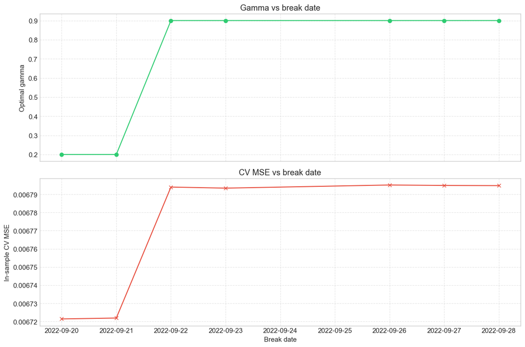

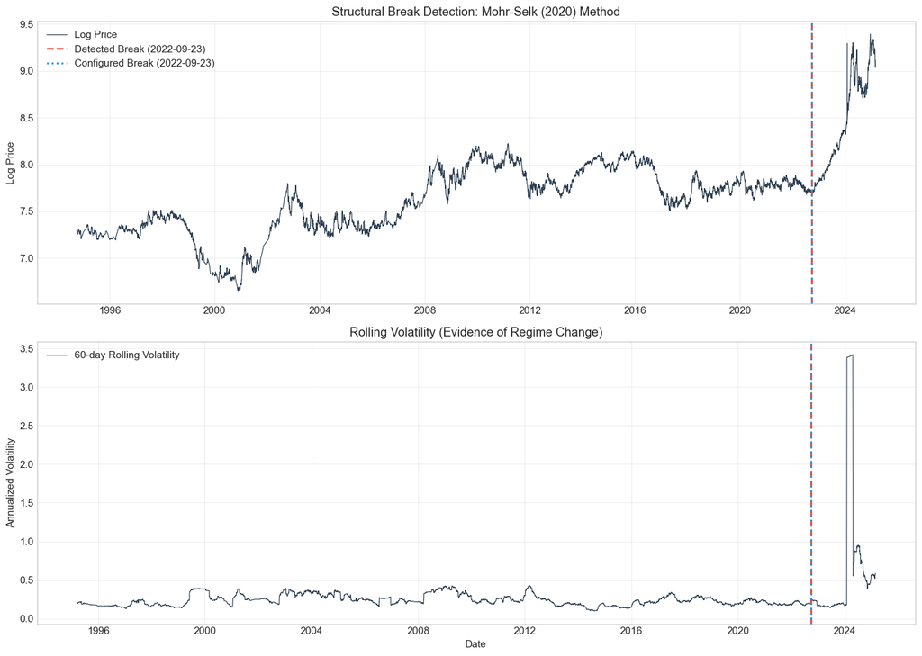

```
break index is  6117 break date is  2022-09-23
```

The Mohr–Selk detector flags a break at index 6117 (2022-09-23). Even by eye the big jump feels like it climaxes in 2024 (El Niño), but a 2022 start is still plausible: it captures the earlier shift in mean/vol driven by tightening supply conditions that lead into the 2024 spike. So the detected break is economically interpretable as the onset of the regime that later peaks with El Niño.

## 4. Experiment Configuration

```
Experiment Configuration:
  Features: ['log_price_lagt']
  Target: log_return_forecast_target
  Training set: 6,694 observations
  Test set (OOS): 40 observations
  OOS Start: 2025-01-02
  Break index (training): 6116
  MFV Folds (Q): 4
```

## 5. Model Training

### 5.1 Non-Parametric Benchmarks

```
LocalPolynomialEngine will use device: cuda
Creating bandwidth grid with T=6694, d=1
Generated bandwidth grid: [0.01717366 0.02864739 0.04778673 0.07971307 0.13296941 0.22180635
 0.36999529 0.61718934 1.02953386 1.71736599]
NP Configuration:
  Kernel: Epanechnikov
  Local Engine: Local Linear (order=1)
  Dimension: 1
  Bandwidth grid: 10 candidates
  Range: [0.0172, 1.7174]
```

```
Training Pre-Break Local Linear Model...
  Training size: 6,116
  Selecting bandwidth via MFV...
Set block size to 1223 for training length 6116 and Q=4.
  Selected bandwidth: 1.717366
  MFV MSE: 0.00025423
  Model trained.
```

```
Training Post-Break Local Linear Model...
  Training size: 578
  Selecting bandwidth via MFV...
Set block size to 115 for training length 578 and Q=4.
  Selected bandwidth: 1.717366
  MFV MSE: 0.00767773
  Model trained.
```

```
Training Weighted Local Linear (WLL) Model...
  Tuning gamma via MFV...
  Gamma grid: 21 candidates
Set block size to 115 for training length 578 and Q=4.
  Optimal gamma: 0.9500
  Interpretation: 95.0% weight on pre-break model
  MFV MSE: 0.00680709
  Model trained.
```

### 5.2 Machine Learning Competitors

```
Training Random Forest...
  Grid size: 12 combinations
  Running MFV hyperparameter tuning...
Set block size to 1338 for training length 6694 and Q=4.
  Best params: {'n_estimators': 500, 'max_depth': 5, 'min_samples_leaf': 20, 'max_features': 'sqrt'}
  MFV MSE: 0.00082170
  Model trained.
```

```
Training XGBoost...
  Grid size: 32 combinations
  Running MFV hyperparameter tuning...
Set block size to 1338 for training length 6694 and Q=4.
  Best params: {'n_estimators': 200, 'max_depth': 3, 'learning_rate': 0.05, 'subsample': 1.0, 'colsample_bytree': 0.7}
  MFV MSE: 0.00082941
  Model trained.
```

### 5.3 ML Extension: Weighted ML Combinations

```
Training Weighted RF Combo...
Set block size to 115 for training length 578 and Q=4.
  Optimal gamma: 0.7000
Training Weighted XGB Combo...
Set block size to 115 for training length 578 and Q=4.
  Optimal gamma: 1.0000
All models trained.
```

## 6. Out-of-Sample Evaluation

```
Generating out-of-sample predictions...

======================================================================
MEAN SQUARED FORECAST ERROR (MSFE) RESULTS
======================================================================
 Rank         Model     MSFE    RMSFE  Relative (%)
    1           WLL 0.000942 0.030700      0.000000
    2  Pre-Break LL 0.000943 0.030706      0.042678
    3     XGB Combo 0.000950 0.030824      0.808613
    4      RF Combo 0.001003 0.031663      6.371883
    5 Post-Break LL 0.001101 0.033176     16.778409
    6 Random Forest 0.001239 0.035196     31.433508
    7       XGBoost 0.001304 0.036115     38.387813
======================================================================

Best Model: WLL (MSFE = 0.00094248)
```

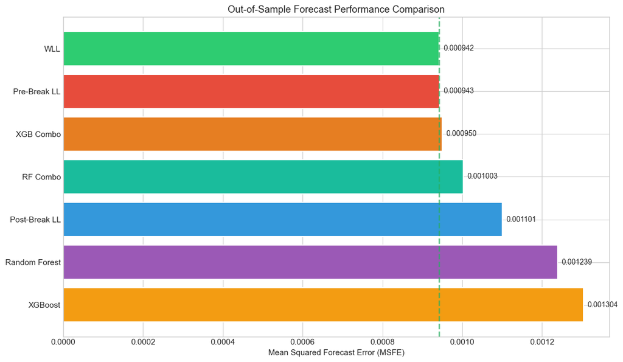

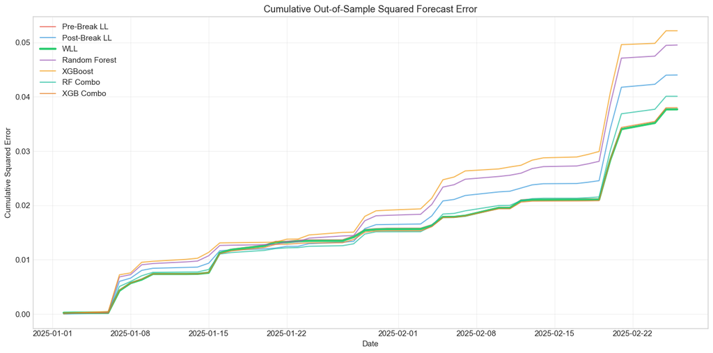

## 7. Modified Diebold-Mariano Test

```
MDM Test Statistics (positive = row model worse than column):
               Pre-Break LL  Post-Break LL    WLL  Random Forest  XGBoost  RF Combo  XGB Combo
Pre-Break LL          0.000         -1.218  0.062         -1.733   -1.930    -0.807     -0.336
Post-Break LL         1.218          0.000  1.285         -3.218   -3.324     1.715      1.387
WLL                  -0.062         -1.285  0.000         -1.804   -2.000    -0.889     -0.503
Random Forest         1.733          3.218  1.804          0.000   -3.396     2.435      1.932
XGBoost               1.930          3.324  2.000          3.396    0.000     2.659      2.134
RF Combo              0.807         -1.715  0.889         -2.435   -2.659     0.000      0.998
XGB Combo             0.336         -1.387  0.503         -1.932   -2.134    -0.998      0.000

P-Values:
               Pre-Break LL  Post-Break LL    WLL  Random Forest  XGBoost  RF Combo  XGB Combo
Pre-Break LL          1.000          0.231  0.951          0.091    0.061     0.425      0.738
Post-Break LL         0.231          1.000  0.206          0.003    0.002     0.094      0.173
WLL                   0.951          0.206  1.000          0.079    0.052     0.379      0.618
Random Forest         0.091          0.003  0.079          1.000    0.002     0.020      0.061
XGBoost               0.061          0.002  0.052          0.002    1.000     0.011      0.039
RF Combo              0.425          0.094  0.379          0.020    0.011     1.000      0.324
XGB Combo             0.738          0.173  0.618          0.061    0.039     0.324      1.000
```

## 8. Summary

```
======================================================================
EXPERIMENT SUMMARY
======================================================================

Data:
  Training: 1994-10-04 to 2025-01-02
  Test: 2025-01-02 to 2025-02-26
  Structural break: 2022-09-23

Hyperparameters:
  Pre-break bandwidth: 1.717366
  Post-break bandwidth: 1.717366
  WLL gamma: 0.9500
  RF Combo gamma: 0.7000
  XGB Combo gamma: 1.0000

Results (MSFE):
  1. WLL: 0.00094248 (0.00%)
  2. Pre-Break LL: 0.00094288 (0.04%)
  3. XGB Combo: 0.00095010 (0.81%)
  4. RF Combo: 0.00100254 (6.37%)
  5. Post-Break LL: 0.00110062 (16.78%)
  6. Random Forest: 0.00123874 (31.43%)
  7. XGBoost: 0.00130428 (38.39%)

Key Comparisons:
  WLL vs Post-Break LL: -14.37%
  WLL vs Random Forest: -23.92%

======================================================================
```

```
Results saved to: w:\Research\NP\Cocoa\output\experiment_results
```

## Hypotheses and how we test them

Main question: does explicit break-aware weighting (WLL) adapt faster and give better post-break forecasts than break-agnostic ML (RF, XGB)?

- H0 (overall): On the post-break test sample, WLL MSFE < RF and WLL MSFE < XGB.
- H1 (early): In the first K days of the post-break test, the WLL cumulative squared error grows slower than RF and XGB.

How we check:

- Use the saved `predictions_*.csv` from the main run.
- Compute overall MSFE for WLL, RF, XGB (H0).
- Compute and exame MSFE on short windows (1–20, 21–40) and the winning model in each state

```
Loaded predictions file: predictions_20251201_205941.csv
```

|  | Model | MSFE | Rel_to_WLL_% |
| --- | --- | --- | --- |
| 0 | WLL | 0.000942 | 0.000000 |
| 1 | Random Forest | 0.001239 | 31.433508 |
| 2 | XGBoost | 0.001304 | 38.387814 |

|  | date | CSE_WLL | CSE_Random Forest | CSE_XGBoost |
| --- | --- | --- | --- | --- |
| 0 | 2025-01-02 | 0.000223 | 0.000004 | 0.000014 |
| 1 | 2025-01-03 | 0.000246 | 0.000152 | 0.000207 |
| 2 | 2025-01-06 | 0.000254 | 0.000353 | 0.000459 |
| 3 | 2025-01-07 | 0.004293 | 0.006832 | 0.007218 |
| 4 | 2025-01-08 | 0.005685 | 0.007247 | 0.007566 |

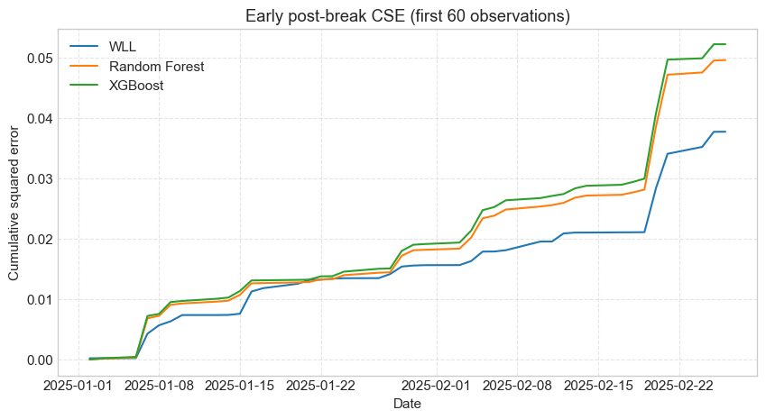

|  | Model | CSE_first_K | Rel_to_WLL_% |
| --- | --- | --- | --- |
| 0 | WLL | 0.037699 | 0.000000 |
| 1 | Random Forest | 0.049550 | 31.433508 |
| 2 | XGBoost | 0.052171 | 38.387814 |

|  | Window | Model | MSFE | Rel_to_WLL_% |
| --- | --- | --- | --- | --- |
| 0 | 1-20 | WLL | 0.000770 | 0.000000 |
| 1 | 1-20 | Random Forest | 0.000859 | 11.587360 |
| 2 | 1-20 | XGBoost | 0.000899 | 16.836735 |
| 3 | 21-40 | WLL | 0.001115 | 0.000000 |
| 4 | 21-40 | Random Forest | 0.001619 | 45.131825 |
| 5 | 21-40 | XGBoost | 0.001709 | 53.262919 |